# Dhading District Profile

Author

UN Nepal & iMMAP

Modified

September 19, 2026

# Introduction

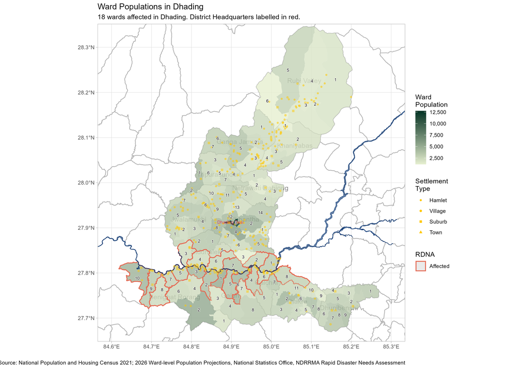

17.19% (14,375) out of the 83,622 [households](https://censusresults.nsonepal.gov.np/) in Dhading are in the poorest quintile of households nationally, below the average for Nepal.

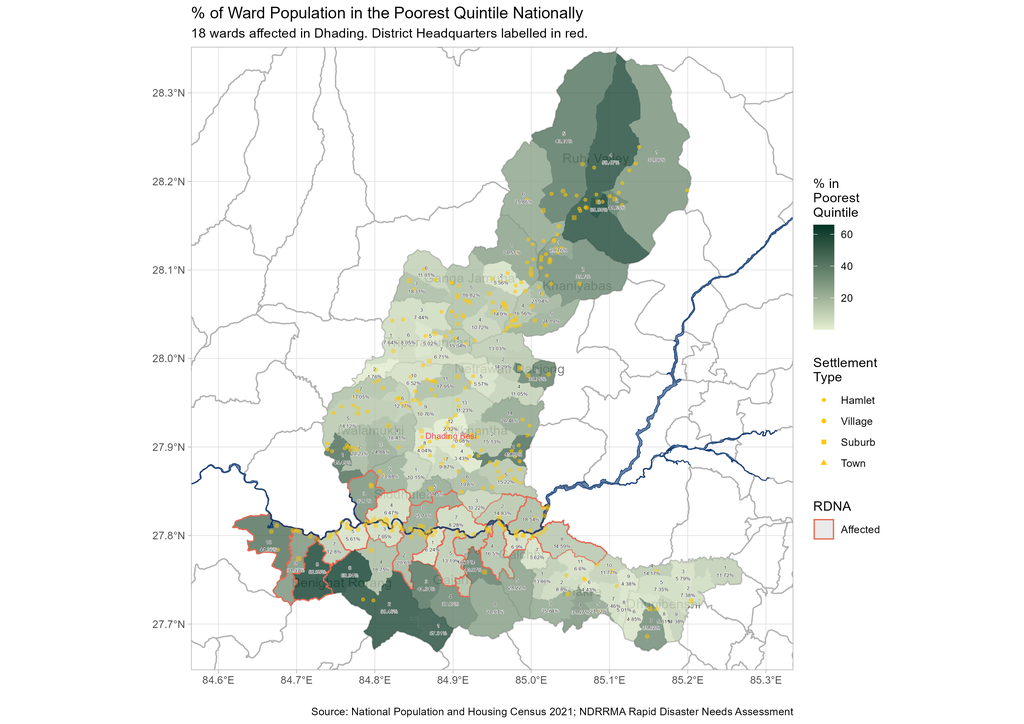

The poorest parts of the district are in the south of Benighat Rorang and in the upper reaches of the Rubi Valley. Although Benighat Rorang-8 is quite poor, it is only marginally affected and had very limited exposure to the river. 2,976 (20.7%) out of the 14,375 persons in the poorest quintile live in the affected wards.

As of the 2021 Census, there were 1,672 people with disabilities in the district, though it should be noted that this figure relies on self-reporting, so the actual number might be much higher.

Clicking on any of the maps will lead you to a larger version of the map.

# Needs

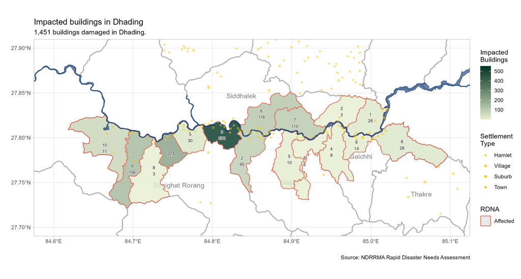

Based on the NDRRMA Rapid Disaster Needs Assessment, 1,451 buildings were damaged in the floods. This damage to housing private buildings has affected 6,639 people. Benighat Rorang-3 has the highest number of damaged buildings out of all the wards in Dhading.

Economic impacts and losses in Dhading, NDRRMA Rapid Disaster Needs Assessment

| municipality | Businesses_affected | Total_damage_incl._households_assets_npr_crore |
| --- | --- | --- |
| Benighat Rorang | 893 | 757.33 |
| Siddhalek | 106 | 134.65 |
| Gajuri | 62 | 81.34 |
| Galchhi | 105 | 61.10 |

277 hectares of agricultural land was impacted by the flooding. Considering that Dhading was further downstream than some of the other affected areas, this is considerably less than the 1,228 hectares affected in Nuwakot and less than the 283 hectares in Rasuwa.

Total affected hectares of agricultural land

| municipality | total_affected_hectares |
| --- | --- |
| Galchhi | 101 |
| Gajuri | 82 |
| Siddhalek | 60 |
| Benighat Rorang | 34 |

## Comparison between districts

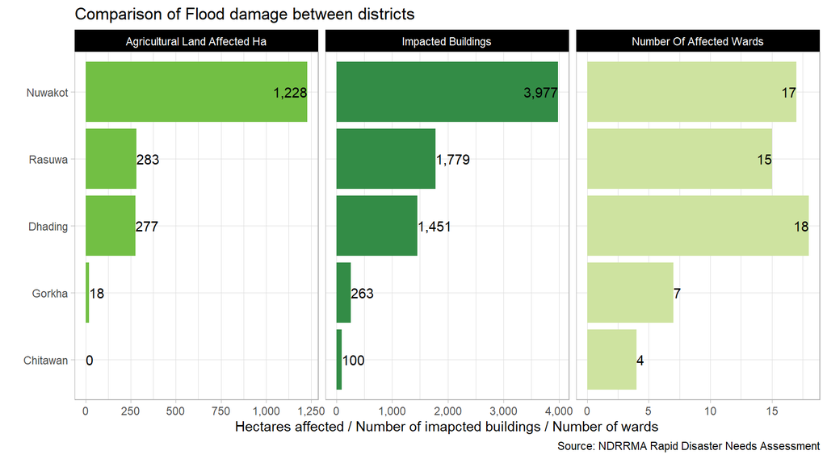

# Response

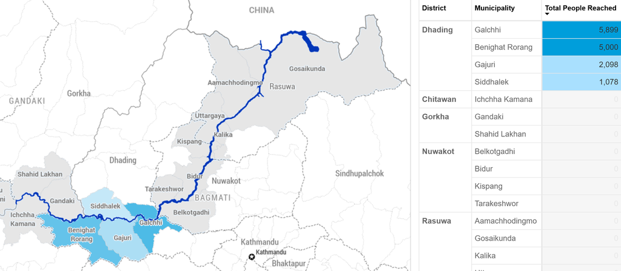

NDRRMA 5Ws 20260918

Galchhi and Benighat Rorang are the focuses of the response activities in Dhading, in spite of damage being much greater in Benighat Rorang. From the beneficiary frequencies table below (which is inclusive of double counting, and thus indicative of where agencies have focused their resources), we can see that affected persons have been reached by both WASH and Shelter activities.

Clicking on any of the 5W maps and tables will lead to the 5Ws PowerBI dashboard.

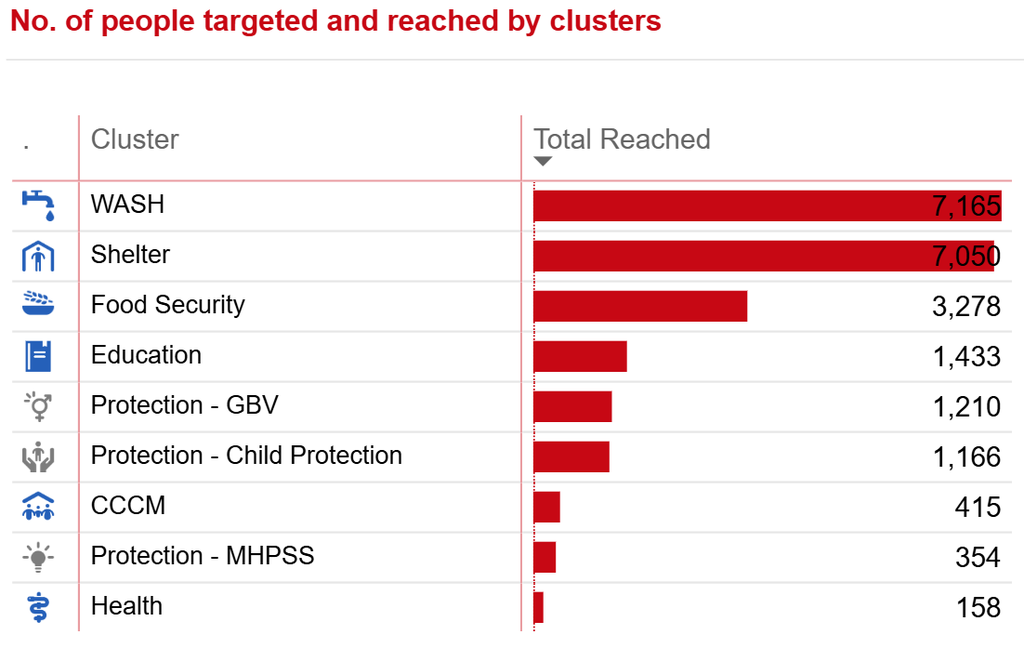

NDRRMA 5Ws 20260918

Granular reporting is currently quite poor in Dhading: 15.92% of the beneficiary frequencies were reported at the ward level. To date, no beneficiaries have been reported in Benighat Rorang-3, the most affected ward, and only 50 were reported in Benighat Rorang-7, the second-most affected ward.

## Agency presence

Agency presence is highest Gajuri, though there are 18 Lead Agencies and 13 Implementing Partners in Dhading, far fewer than the 45 ans 34 in Nuwakot and the 32 ans 23 in Rasuwa.

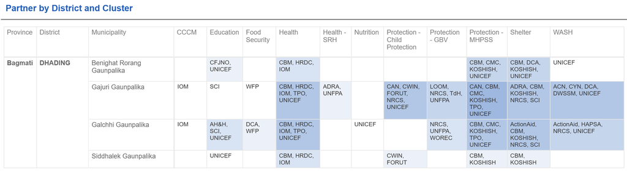

NDRRMA 5Ws 20260918

# References and useful datasets

## Interactive Reference Table

|  | municipality | ward | impacted_buildings | total_households | population_2026 | sex_ratio | population_density | population_2026_male | population_2026_female | total_dependency_ratio | adm3_pcode |
| --- | --- | --- | --- | --- | --- | --- | --- | --- | --- | --- | --- |
| 1 | Siddhalek | 3 |  | 682 | 2337 | 95.72 | 152.11 | 1096 | 1241 | 56.36 | NP0330407 |
| 2 | Siddhalek | 4 |  | 680 | 2401 | 91.45 | 151.76 | 1099 | 1302 | 51.74 | NP0330407 |
| 3 | Siddhalek | 6 | 118 | 735 | 2700 | 99.27 | 158.91 | 1288 | 1412 | 51.99 | NP0330407 |
| 4 | Siddhalek | 7 | 110 | 990 | 3731 | 96.04 | 268.54 | 1755 | 1976 | 48.39 | NP0330407 |
| 5 | Benighat Rorang | 3 | 553 | 1189 | 4532 | 109.88 | 431.07 | 2315 | 2217 | 51.29 | NP0330408 |
| 6 | Benighat Rorang | 5 | 30 | 766 | 3049 | 99.81 | 281.39 | 1491 | 1558 | 46.47 | NP0330408 |
| 7 | Benighat Rorang | 7 | 224 | 719 | 2886 | 102.38 | 313.04 | 1424 | 1462 | 48.73 | NP0330408 |
| 8 | Benighat Rorang | 9 | 156 | 785 | 3438 | 98.61 | 187.29 | 1674 | 1764 | 62.14 | NP0330408 |
| 9 | Benighat Rorang | 10 | 71 | 1019 | 4652 | 101.71 | 171.91 | 2285 | 2367 | 59.83 | NP0330408 |
| 10 | Gajuri | 1 |  | 1427 | 5214 | 98.47 | 552.34 | 2581 | 2633 | 48.9 | NP0330409 |

[output cut: 8 more lines]

## Useful links and datasets

### [Digitised NDRRMA Municipal Damage Tables](https://drive.google.com/drive/folders/1GehdusDNji6HGQGQ6R7cEHNJC3BwwNau?usp=drive_link)

### [5W Dashboard](https://app.powerbi.com/view?r=eyJrIjoiZTQ0MGE1NWEtOWJlMi00YmU4LWFhYjMtMTg0OTRmNTRmMGQ1IiwidCI6IjBmOWUzNWRiLTU0NGYtNGY2MC1iZGNjLTVlYTQxNmU2ZGM3MCIsImMiOjh9)

### [Consolidated Census ward-level household and population](https://drive.google.com/drive/folders/1gNkJJR6Q4psoCrWyBcUyzqL9wcKVVRbb?usp=drive_link)

Variables include a breakdown of housing materials, wealth quintile, school attendance and household WASH.

### [Logistics Cluster Access Map](https://logie.logcluster.org/?op=npl)

Updated regularly.